# Modelagem Preditiva Avançada

## Regressão Logística

#### Datasets & PPT: https://github.com/rbarsotti/MBA/archive/master.zip

| Feature | Descrição | Tipo |
| --- | --- | --- |
| GENDER | Gênero | Flag |
| AGE | Idade | Real |
| DEBT | Dívidas | Real |
| MARRIED | Estado Civil | Flag |
| BANK_CUSTOMER | Cliente do Banco | Flag |
| EDUCATION_LEVEL | Nível de Educação (Médio, Superior, etc..) | Categorical |
| YEARS_EMPLOYED | Anos de Trabalho | Real |
| PRIOR_DEFAULT | Histórico de Calote/Atraso | Flag |
| EMPLOYED | Situação Empregatícia | Flag |
| CITIZEN | Cidadão USA | Flag |
| INCOME | Renda | Real |
| APPROVED | Crédito Aprovado ou Não | Target |

Passo 1)

Primeiramente vamos importar os seguinter pacotes:

caret: Biblioteca para funcionalidade de ML

mlbench: Biblioteca para Validação de Modelos

ggplot2: Biblioteca para visualização de dados

pROC: Curva ROC

ROCR: Curva ROC

### Importando Bibliotecas e Dados

```r
library(caret)
library(datasets)
library(mlbench)
library(ggplot2)

library(pROC)
library(ROCR)
```

Passo 2)

Agora vamos carregar o dataset, com cabeçalho (header=TRUE) e o separador de colunas sendo ','.

### Análise de Dados

```r
df <- read.csv(file="/home/barsotti/Desktop/BostonCredit_Theory.csv", header=TRUE, sep=",")
```

Passo 3)

Agora vamos fazer uma rápida análise dos dados buscando identificar algumas relações visualmente e também verificar a qualidade dos dados.

```r
head(df)
```

| GENDER | AGE | DEBT | MARRIED | BANK_CUSTOMER | EDUCATION_LEVEL | YEARS_EMPLOYED | PRIOR_DEFAULT | EMPLOYED | CITIZEN | INCOME | APPROVED |
| --- | --- | --- | --- | --- | --- | --- | --- | --- | --- | --- | --- |
| 1 | 30.83 | 0.000 | 0 | 1 | w | 1.25 | 1 | 1 | 1 | 0 | Yes |
| 0 | 58.67 | 4.460 | 0 | 1 | q | 3.04 | 1 | 1 | 1 | 560 | Yes |
| 0 | 24.50 | 0.500 | 0 | 1 | q | 1.50 | 1 | 0 | 1 | 824 | Yes |
| 1 | 27.83 | 1.540 | 0 | 1 | w | 3.75 | 1 | 1 | 1 | 3 | Yes |
| 1 | 20.17 | 5.625 | 0 | 1 | w | 1.71 | 1 | 0 | 0 | 0 | Yes |
| 1 | 32.08 | 4.000 | 0 | 1 | m | 2.50 | 1 | 0 | 1 | 0 | Yes |

```r
summary(df)
```

```
     GENDER            AGE             DEBT        MARRIED BANK_CUSTOMER
 Min.   :0.0000   Min.   :13.75   Min.   : 0.000   0:499   Min.   : 0.0000
 1st Qu.:0.0000   1st Qu.:22.58   1st Qu.: 1.040   1:152   1st Qu.: 1.0000
 Median :1.0000   Median :28.42   Median : 2.835   l:  2   Median : 1.0000
 Mean   :0.6891   Mean   :31.50   Mean   : 4.830           Mean   : 0.7979
 3rd Qu.:1.0000   3rd Qu.:38.25   3rd Qu.: 7.500           3rd Qu.: 1.0000
 Max.   :1.0000   Max.   :76.75   Max.   :28.000           Max.   :11.0000

 EDUCATION_LEVEL YEARS_EMPLOYED   PRIOR_DEFAULT       EMPLOYED      CITIZEN
 c      :133     Min.   : 0.000   Min.   :0.0000   Min.   :0.0000   0: 53
 q      : 75     1st Qu.: 0.165   1st Qu.:0.0000   1st Qu.:0.0000   1:598
 w      : 63     Median : 1.000   Median :1.0000   Median :0.0000   p:  2
 i      : 55     Mean   : 2.244   Mean   :0.5345   Mean   :0.4395
 aa     : 52     3rd Qu.: 2.625   3rd Qu.:1.0000   3rd Qu.:1.0000
 ff     : 50     Max.   :28.500   Max.   :1.0000   Max.   :1.0000
 (Other):225
     INCOME       APPROVED
 Min.   :     0   No :357
 1st Qu.:     0   Yes:296
 Median :     5
 Mean   :  1014
 3rd Qu.:   400
 Max.   :100000
```

Passo 4)

Agora vamos particionar o dataset em treino/teste. Para isso definimos "p=0.7", isto é 70% da base será escolhida aleatóriamente para treino e 30% para teste do modelo.

Observe também que o "set.seed(x)" garante que ao replicarmos essa partição em outro computador por exemplo, os mesmos dados irão respectivamente prar treino e teste

```r
set.seed(280)
trainIndex <- createDataPartition(df$APPROVED, p = .7, list = FALSE)

df$APPROVED <- as.factor(df$APPROVED)
```

```r
dfTrain <- df[ trainIndex,]
dfTest  <- df[-trainIndex,]
```

Passo 5)

Observe que em "method" definimos "glm" de generalized linear model e que definimos variável target sendo APPROVED e colocamos todas as outras variáveis como preditoras. Observe também que agora incluímos o parâmetro de 10 fold cross validation na hora do treino do modelo

```r
set.seed(130)
options(warn=-1)
cv <- trainControl(method = "repeatedcv", number = 10, savePredictions = TRUE,
                  summaryFunction=twoClassSummary, classProbs = TRUE)


model <- train(APPROVED~., data = dfTrain, method = "glm",
                   metric="ROC",trControl = cv, control = list(maxit = 50))
```

Passo 6)

Chamando o modelo obtemos informações como:

Número de amostras no treino

Número de features preditoras

Sensitividade e Specificidade do Modelo

```r
model
```

```
Generalized Linear Model

458 samples
 11 predictor
  2 classes: 'No', 'Yes'

No pre-processing
Resampling: Cross-Validated (10 fold, repeated 1 times)
Summary of sample sizes: 412, 412, 412, 412, 413, 413, ...
Resampling results:

  ROC       Sens   Spec
  0.898619  0.812  0.8645238
```

Passo 7)

$z = \alpha_1(X_1) + \alpha_2(X_2) + \alpha_3(X_3) ....$

$z = \alpha_1(GENDER) + \alpha_2(AGE) +\alpha_3(DEBT) ....$

$Pr(Approved=Yes) = \frac{1}{1+e^{-z}}$

```r
dfPred <- predict(model, newdata=dfTest)
```

Passo 8)

Adicionando matriz de confusão para validação do modelo logístico.

### Matriz de Confusao

```r
confusionMatrix(data=dfPred, dfTest$APPROVED)
```

```
Confusion Matrix and Statistics

          Reference
Prediction No Yes
       No  98   7
       Yes  9  81

               Accuracy : 0.9179
                 95% CI : (0.8702, 0.9524)
    No Information Rate : 0.5487
    P-Value [Acc > NIR] : <2e-16

                  Kappa : 0.8347
 Mcnemar's Test P-Value : 0.8026

            Sensitivity : 0.9159
            Specificity : 0.9205
         Pos Pred Value : 0.9333
         Neg Pred Value : 0.9000
             Prevalence : 0.5487
         Detection Rate : 0.5026
   Detection Prevalence : 0.5385
      Balanced Accuracy : 0.9182

       'Positive' Class : No
```

Passo 9)

Agora podemos fazer o score do modelo na base de teste e obter as probabilidades de cada classe de acordo com o modelo

```r
dfProbs <- predict(model, newdata=dfTest, type="prob")
head(dfProbs)
```

|  | No | Yes |
| --- | --- | --- |
| 2 | 0.1191543 | 0.88084571 |
| 3 | 0.2927482 | 0.70725177 |
| 13 | 0.5275177 | 0.47248227 |
| 14 | 0.9070458 | 0.09295417 |
| 16 | 0.4968018 | 0.50319816 |
| 18 | 0.1896379 | 0.81036208 |

Passo 10)

Agora usando a biblioteca pROC vamos fazer um plot da curva ROC

0.95911214953271

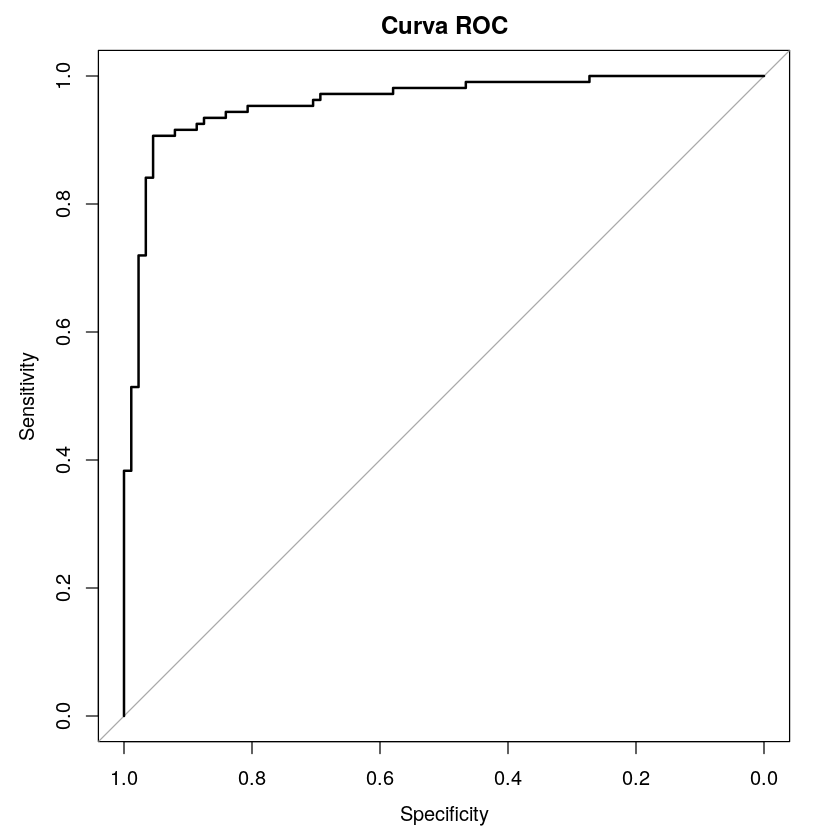

```r
gbm.ROC <- roc(predictor=dfProbs$Yes,
               response=dfTest$APPROVED,
               levels=rev(levels(dfTest$APPROVED)))

gbm.ROC$auc
plot(gbm.ROC,main="Curva ROC")
```

Passo 11)

Utilizando a função VarImp do mlbench e plotando sua tabela vemos em oredem as features mais importantes do modelos

```
ROC curve variable importance

                Importance
PRIOR_DEFAULT       0.8563
YEARS_EMPLOYED      0.7158
EMPLOYED            0.7097
INCOME              0.6681
AGE                 0.6006
DEBT                0.5959
EDUCATION_LEVEL     0.5829
BANK_CUSTOMER       0.5657
MARRIED             0.5561
CITIZEN             0.5262
GENDER              0.5006
```

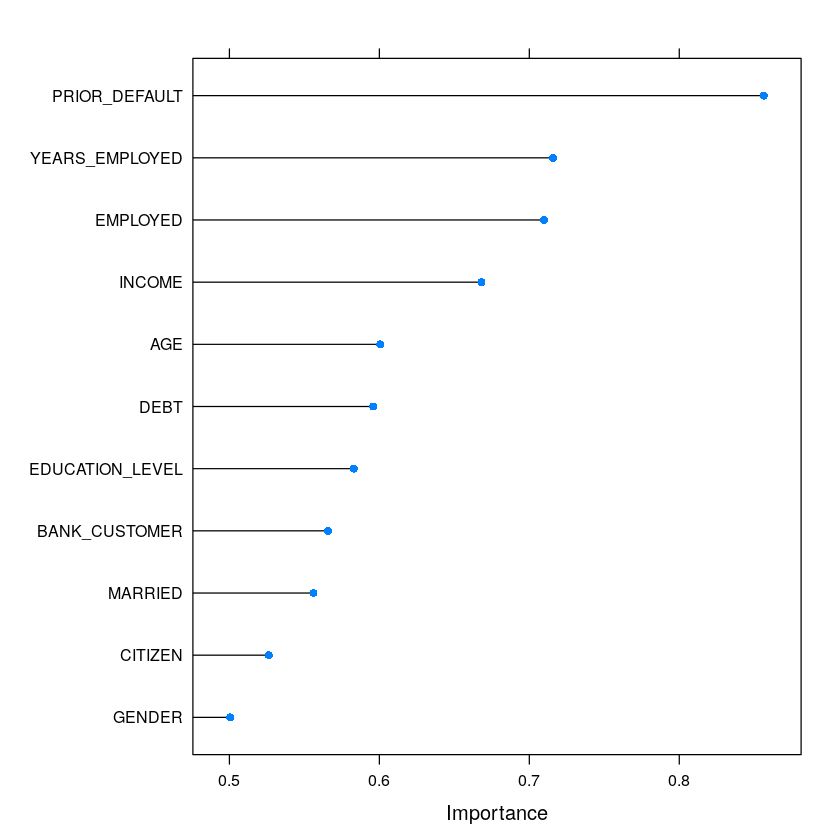

```r
imp <- varImp(model, useModel=FALSE, scale=FALSE)
imp
plot(imp)
```